# Prosper Loan Exploration

```python
import pandas as pd
import numpy as np
import matplotlib.pyplot as plt
import seaborn as sb
%matplotlib inline
```

## Preliminary Wrangling

This document explores a dataset containing borrower rate and 80 attributes for 113937 borrowing records.

### Gathering

```python
loan=pd.read_csv("prosperLoanData.csv")
loan.head()
```

|  | ListingKey | ListingNumber | ListingCreationDate | CreditGrade | Term | LoanStatus | ClosedDate | BorrowerAPR | BorrowerRate | LenderYield | ... | LP_ServiceFees | LP_CollectionFees | LP_GrossPrincipalLoss | LP_NetPrincipalLoss | LP_NonPrincipalRecoverypayments | PercentFunded | Recommendations | InvestmentFromFriendsCount | InvestmentFromFriendsAmount | Investors |
| --- | --- | --- | --- | --- | --- | --- | --- | --- | --- | --- | --- | --- | --- | --- | --- | --- | --- | --- | --- | --- | --- |
| 0 | 1021339766868145413AB3B | 193129 | 2007-08-26 19:09:29.263000000 | C | 36 | Completed | 2009-08-14 00:00:00 | 0.16516 | 0.1580 | 0.1380 | ... | -133.18 | 0.0 | 0.0 | 0.0 | 0.0 | 1.0 | 0 | 0 | 0.0 | 258 |
| 1 | 10273602499503308B223C1 | 1209647 | 2014-02-27 08:28:07.900000000 | NaN | 36 | Current | NaN | 0.12016 | 0.0920 | 0.0820 | ... | 0.00 | 0.0 | 0.0 | 0.0 | 0.0 | 1.0 | 0 | 0 | 0.0 | 1 |
| 2 | 0EE9337825851032864889A | 81716 | 2007-01-05 15:00:47.090000000 | HR | 36 | Completed | 2009-12-17 00:00:00 | 0.28269 | 0.2750 | 0.2400 | ... | -24.20 | 0.0 | 0.0 | 0.0 | 0.0 | 1.0 | 0 | 0 | 0.0 | 41 |
| 3 | 0EF5356002482715299901A | 658116 | 2012-10-22 11:02:35.010000000 | NaN | 36 | Current | NaN | 0.12528 | 0.0974 | 0.0874 | ... | -108.01 | 0.0 | 0.0 | 0.0 | 0.0 | 1.0 | 0 | 0 | 0.0 | 158 |
| 4 | 0F023589499656230C5E3E2 | 909464 | 2013-09-14 18:38:39.097000000 | NaN | 36 | Current | NaN | 0.24614 | 0.2085 | 0.1985 | ... | -60.27 | 0.0 | 0.0 | 0.0 | 0.0 | 1.0 | 0 | 0 | 0.0 | 20 |

5 rows × 81 columns

### Assessing

```python
loan.shape
```

```
(113937, 81)
```

```python
loan.describe()
```

|  | ListingNumber | Term | BorrowerAPR | BorrowerRate | LenderYield | EstimatedEffectiveYield | EstimatedLoss | EstimatedReturn | ProsperRating (numeric) | ProsperScore | ... | LP_ServiceFees | LP_CollectionFees | LP_GrossPrincipalLoss | LP_NetPrincipalLoss | LP_NonPrincipalRecoverypayments | PercentFunded | Recommendations | InvestmentFromFriendsCount | InvestmentFromFriendsAmount | Investors |
| --- | --- | --- | --- | --- | --- | --- | --- | --- | --- | --- | --- | --- | --- | --- | --- | --- | --- | --- | --- | --- | --- |
| count | 1.139370e+05 | 113937.000000 | 113912.000000 | 113937.000000 | 113937.000000 | 84853.000000 | 84853.000000 | 84853.000000 | 84853.000000 | 84853.000000 | ... | 113937.000000 | 113937.000000 | 113937.000000 | 113937.000000 | 113937.000000 | 113937.000000 | 113937.000000 | 113937.000000 | 113937.000000 | 113937.000000 |
| mean | 6.278857e+05 | 40.830248 | 0.218828 | 0.192764 | 0.182701 | 0.168661 | 0.080306 | 0.096068 | 4.072243 | 5.950067 | ... | -54.725641 | -14.242698 | 700.446342 | 681.420499 | 25.142686 | 0.998584 | 0.048027 | 0.023460 | 16.550751 | 80.475228 |
| std | 3.280762e+05 | 10.436212 | 0.080364 | 0.074818 | 0.074516 | 0.068467 | 0.046764 | 0.030403 | 1.673227 | 2.376501 | ... | 60.675425 | 109.232758 | 2388.513831 | 2357.167068 | 275.657937 | 0.017919 | 0.332353 | 0.232412 | 294.545422 | 103.239020 |
| min | 4.000000e+00 | 12.000000 | 0.006530 | 0.000000 | -0.010000 | -0.182700 | 0.004900 | -0.182700 | 1.000000 | 1.000000 | ... | -664.870000 | -9274.750000 | -94.200000 | -954.550000 | 0.000000 | 0.700000 | 0.000000 | 0.000000 | 0.000000 | 1.000000 |
| 25% | 4.009190e+05 | 36.000000 | 0.156290 | 0.134000 | 0.124200 | 0.115670 | 0.042400 | 0.074080 | 3.000000 | 4.000000 | ... | -73.180000 | 0.000000 | 0.000000 | 0.000000 | 0.000000 | 1.000000 | 0.000000 | 0.000000 | 0.000000 | 2.000000 |
| 50% | 6.005540e+05 | 36.000000 | 0.209760 | 0.184000 | 0.173000 | 0.161500 | 0.072400 | 0.091700 | 4.000000 | 6.000000 | ... | -34.440000 | 0.000000 | 0.000000 | 0.000000 | 0.000000 | 1.000000 | 0.000000 | 0.000000 | 0.000000 | 44.000000 |
| 75% | 8.926340e+05 | 36.000000 | 0.283810 | 0.250000 | 0.240000 | 0.224300 | 0.112000 | 0.116600 | 5.000000 | 8.000000 | ... | -13.920000 | 0.000000 | 0.000000 | 0.000000 | 0.000000 | 1.000000 | 0.000000 | 0.000000 | 0.000000 | 115.000000 |
| max | 1.255725e+06 | 60.000000 | 0.512290 | 0.497500 | 0.492500 | 0.319900 | 0.366000 | 0.283700 | 7.000000 | 11.000000 | ... | 32.060000 | 0.000000 | 25000.000000 | 25000.000000 | 21117.900000 | 1.012500 | 39.000000 | 33.000000 | 25000.000000 | 1189.000000 |

8 rows × 61 columns

```python
loan.info()
```

```
<class 'pandas.core.frame.DataFrame'>
RangeIndex: 113937 entries, 0 to 113936
Data columns (total 81 columns):
ListingKey                             113937 non-null object
ListingNumber                          113937 non-null int64
ListingCreationDate                    113937 non-null object
CreditGrade                            28953 non-null object
Term                                   113937 non-null int64
LoanStatus                             113937 non-null object
ClosedDate                             55089 non-null object
BorrowerAPR                            113912 non-null float64
BorrowerRate                           113937 non-null float64
LenderYield                            113937 non-null float64
EstimatedEffectiveYield                84853 non-null float64
EstimatedLoss                          84853 non-null float64
EstimatedReturn                        84853 non-null float64
ProsperRating (numeric)                84853 non-null float64
ProsperRating (Alpha)                  84853 non-null object
ProsperScore                           84853 non-null float64
ListingCategory (numeric)              113937 non-null int64
BorrowerState                          108422 non-null object
Occupation                             110349 non-null object
EmploymentStatus                       111682 non-null object
EmploymentStatusDuration               106312 non-null float64
IsBorrowerHomeowner                    113937 non-null bool
CurrentlyInGroup                       113937 non-null bool
GroupKey                               13341 non-null object
DateCreditPulled                       113937 non-null object
CreditScoreRangeLower                  113346 non-null float64
CreditScoreRangeUpper                  113346 non-null float64
FirstRecordedCreditLine                113240 non-null object
CurrentCreditLines                     106333 non-null float64
OpenCreditLines                        106333 non-null float64
TotalCreditLinespast7years             113240 non-null float64
OpenRevolvingAccounts                  113937 non-null int64
OpenRevolvingMonthlyPayment            113937 non-null float64
InquiriesLast6Months                   113240 non-null float64
TotalInquiries                         112778 non-null float64
CurrentDelinquencies                   113240 non-null float64
AmountDelinquent                       106315 non-null float64
```

[output cut: 31 more lines]

```
LP_CustomerPayments                    113937 non-null float64
LP_CustomerPrincipalPayments           113937 non-null float64
LP_InterestandFees                     113937 non-null float64
LP_ServiceFees                         113937 non-null float64
LP_CollectionFees                      113937 non-null float64
LP_GrossPrincipalLoss                  113937 non-null float64
LP_NetPrincipalLoss                    113937 non-null float64
LP_NonPrincipalRecoverypayments        113937 non-null float64
PercentFunded                          113937 non-null float64
Recommendations                        113937 non-null int64
InvestmentFromFriendsCount             113937 non-null int64
InvestmentFromFriendsAmount            113937 non-null float64
Investors                              113937 non-null int64
dtypes: bool(3), float64(50), int64(11), object(17)
memory usage: 68.1+ MB
```

Wrong data types, such as ListingCreationDate (datetime), ProspeRating_Alpha (categorical), CreditGrade etc.

```python
loan.duplicated().sum()
```

```
0
```

No duplicates in the dataset.

```python
#Filter out all the variables that have null values.
loan.isnull().sum()[loan.isnull().sum()!=0]
```

```
CreditGrade                             84984
ClosedDate                              58848
BorrowerAPR                                25
EstimatedEffectiveYield                 29084
EstimatedLoss                           29084
EstimatedReturn                         29084
ProsperRating (numeric)                 29084
ProsperRating (Alpha)                   29084
ProsperScore                            29084
BorrowerState                            5515
Occupation                               3588
EmploymentStatus                         2255
EmploymentStatusDuration                 7625
GroupKey                               100596
CreditScoreRangeLower                     591
CreditScoreRangeUpper                     591
FirstRecordedCreditLine                   697
CurrentCreditLines                       7604
OpenCreditLines                          7604
TotalCreditLinespast7years                697
InquiriesLast6Months                      697
TotalInquiries                           1159
CurrentDelinquencies                      697
AmountDelinquent                         7622
DelinquenciesLast7Years                   990
PublicRecordsLast10Years                  697
PublicRecordsLast12Months                7604
RevolvingCreditBalance                   7604
BankcardUtilization                      7604
AvailableBankcardCredit                  7544
TotalTrades                              7544
TradesNeverDelinquent (percentage)       7544
TradesOpenedLast6Months                  7544
DebtToIncomeRatio                        8554
TotalProsperLoans                       91852
TotalProsperPaymentsBilled              91852
OnTimeProsperPayments                   91852
ProsperPaymentsLessThanOneMonthLate     91852
ProsperPaymentsOneMonthPlusLate         91852
ProsperPrincipalBorrowed                91852
ProsperPrincipalOutstanding             91852
ScorexChangeAtTimeOfListing             95009
LoanFirstDefaultedCycleNumber           96985
dtype: int64
```

Missing values in the dataset.

*What is the structure of your dataset?*

*What is the main features of interest in the dataset?*

- I'm most interested in figuring out what features are best for predicting the borrower rate (interest rate) of loans in the dataset.
- I'm interested in how borrower rate changed in each state in the past few years.

*What features in the dataset do you think will help support your investigation into your features of interest?*

- I expect that the variable CreditGrade, Term, LenderYield, ProsperScore, EmploymentStatus, IsBorrowerHomeowner, CurrentlyInGroup, CreditScoreRangeLower, CreditScoreRangeUpper, DebtToIncomeRatio, LoanOriginationDate have effects on borrower rate.
- The variable LoanOriginationDate, BorrowerState will help me solve the second problem.

```python
#I'll first extract the columns I need in the dateset.
col=["BorrowerRate","CreditGrade", "Term", "LenderYield", "ProsperScore", "EmploymentStatus", "IsBorrowerHomeowner", "CreditScoreRangeLower", "CreditScoreRangeUpper", "DebtToIncomeRatio", "LoanOriginationDate"]
loan_sub=loan.loc[:,loan.columns.isin(col)]
```

### Data Cleaning

```python
loan_clean=loan_sub.copy()
```

#### Define

- Change the data type of CreditGrade into ordinal category.
- Change the data type of Term into nominal category.
- Change the data type of ProsperScore into string and then change it into category.
- Change the data type of LoanOriginationDate into datetime.

#### Code

```python
# CreditGrade
ranking=["AA","A","B","C","D","E","HR","NC"]
creditgrade=pd.api.types.CategoricalDtype(ordered=True,categories=ranking)
loan_clean.CreditGrade=loan_clean.CreditGrade.astype(creditgrade)
# ProsperScore
loan_clean["ProsperScore"]=loan_clean["ProsperScore"].astype(str)
prosper=["11.0","10.0","9.0","8.0","7.0","6.0","5.0","4.0","3.0","2.0","1.0"]
prosperscore=pd.api.types.CategoricalDtype(ordered=True,categories=prosper)
loan_clean.ProsperScore=loan_clean.ProsperScore.astype(prosperscore)
```

```python
loan_clean.Term=loan_clean.Term.astype("category")
loan_clean.EmploymentStatus=loan_clean.EmploymentStatus.astype("category")
loan_clean.LoanOriginationDate=pd.to_datetime(loan_clean.LoanOriginationDate)
```

## Univariate Exploration

*I'll start by looking at the distribution of the main variable of interest for the first question: borrower rate.*

```python
loan_clean.BorrowerRate.describe()
```

```
count    113937.000000
mean          0.192764
std           0.074818
min           0.000000
25%           0.134000
50%           0.184000
75%           0.250000
max           0.497500
Name: BorrowerRate, dtype: float64
```

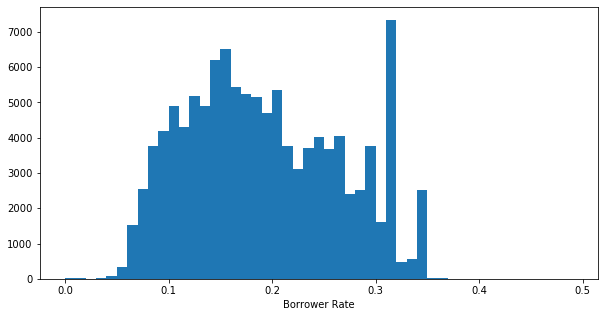

```python
bin_edges1=np.arange(0,0.5,0.01)
plt.figure(figsize=(10,5))
plt.hist(data=loan_clean,x="BorrowerRate",bins=bin_edges1);
plt.xlabel("Borrower Rate");
```

It is a roughly unimodal shape, the borrower rate has a high frequency around 0.15. And it is roughly a right-skewed shape. But, there's a very high frequency around 0.31 and 0.35, making the shape less smoothy.

*Next up, the first predictor variable of interest: CreditGrade.*

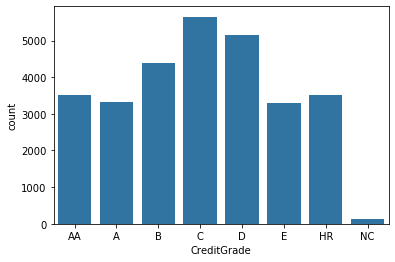

```python
# Decreasing grade from left to right.
base_color=sb.color_palette()[0]
sb.countplot(data=loan_clean,x="CreditGrade",color=base_color)
```

We can see there are more records in B, C, and D grade, and very small portion from the NC grade.

*Let's move to the next variable: Term*

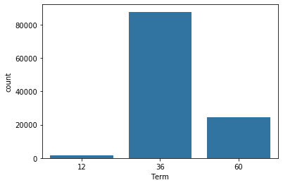

```python
sb.countplot(data=loan_clean,x="Term",color=base_color)
```

*Let's move to next variable: LenderYield.*

```python
loan_clean.LenderYield.describe()
```

```
count    113937.000000
mean          0.182701
std           0.074516
min          -0.010000
25%           0.124200
50%           0.173000
75%           0.240000
max           0.492500
Name: LenderYield, dtype: float64
```

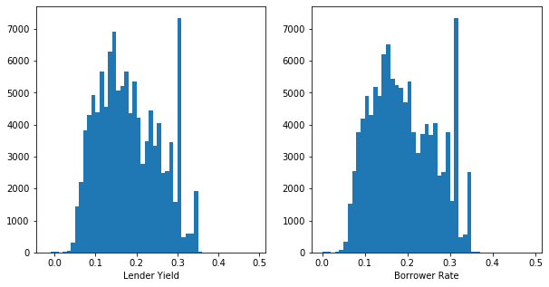

```python
plt.subplots(figsize=(10,5))
plt.subplot(1,2,1)
bin_edges2=np.arange(-0.02,0.5,0.01)
plt.hist(data=loan_clean,x="LenderYield",bins=bin_edges2);
plt.xlabel("Lender Yield");
plt.subplot(1,2,2)
bin_edges1=np.arange(0,0.5,0.01)
plt.hist(data=loan_clean,x="BorrowerRate",bins=bin_edges1);
plt.xlabel("Borrower Rate");
```

I noticed the LenderYield and Borrower Rate have similar shape of histogram, and LenderYield is a bit more volatile than the Borrower Rate.

*Let move to the next variable: ProsperScore*

```python
loan_clean.ProsperScore.describe()
```

```
count     84853
unique       11
top         4.0
freq      12595
Name: ProsperScore, dtype: object
```

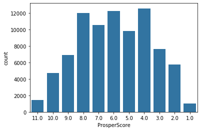

```python
# Decreasing grade from left to right.
sb.countplot(data=loan_clean, x="ProsperScore",color=base_color)
```

We can see most of the records have a prosper score in the middle, between 8 and 4.

*Let move to the next variable: EmploymentStatus*

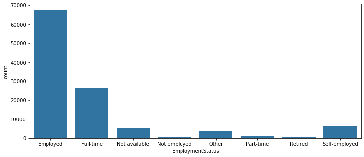

```python
plt.figure(figsize=(12,5))
sb.countplot(data=loan_clean,x="EmploymentStatus",color=base_color)
```

Most borrowers are employed and full-time.

*Let move to the next variable: IsBorrowerHomeowner*

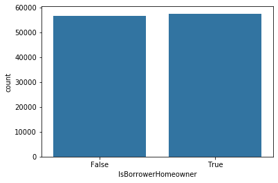

```python
sb.countplot(data=loan_clean,x="IsBorrowerHomeowner",color=base_color)
```

The number of homeowners and none-homeowners are almost the same.

*Let move to the next variable: CreditScoreRangeLower & CreditScoreRangeUpper*

```python
loan_clean.CreditScoreRangeLower.describe()
```

```
count    113346.000000
mean        685.567731
std          66.458275
min           0.000000
25%         660.000000
50%         680.000000
75%         720.000000
max         880.000000
Name: CreditScoreRangeLower, dtype: float64
```

```python
loan_clean.CreditScoreRangeUpper.describe()
```

```
count    113346.000000
mean        704.567731
std          66.458275
min          19.000000
25%         679.000000
50%         699.000000
75%         739.000000
max         899.000000
Name: CreditScoreRangeUpper, dtype: float64
```

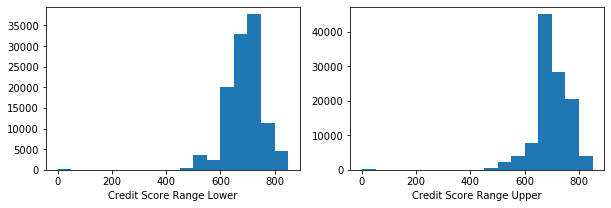

```python
plt.subplots(figsize=(10,3))
plt.subplot(1,2,1)
bin_edges4=np.arange(0,900,50)
plt.hist(data=loan_clean,x="CreditScoreRangeLower",bins=bin_edges4);
plt.xlabel("Credit Score Range Lower")
plt.subplot(1,2,2)
bin_edges4=np.arange(0,900,50)
plt.hist(data=loan_clean,x="CreditScoreRangeUpper",bins=bin_edges4);
plt.xlabel("Credit Score Range Upper")
```

The shapes of histograms of credit score range lower and upper are similar. Most borrowers has a credit score ranger lower and upper between 600 and 800.

*Let move to the next variable: DebtToIncomeRatio*

```python
loan_clean.DebtToIncomeRatio.describe()
```

```
count    105383.000000
mean          0.275947
std           0.551759
min           0.000000
25%           0.140000
50%           0.220000
75%           0.320000
max          10.010000
Name: DebtToIncomeRatio, dtype: float64
```

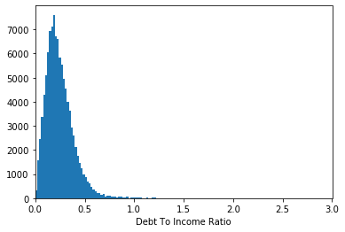

```python
bin_edges9=np.arange(0,11,0.02)
plt.hist(data=loan_clean, x="DebtToIncomeRatio",bins=bin_edges9);
plt.xlim((0,3));
plt.xlabel("Debt To Income Ratio");
```

```python
loan_clean.query("DebtToIncomeRatio>=3").shape
```

```
(409, 11)
```

It is also a right skewed shape, most borrowers has a 0.25 debt to income ratio. Only 409 records have a DebtToIncomeRatio over 3, but I don't need to delete them as well.

*Let move to the next variable: LoanOriginationDate*

- I decided to extract the year in the date and analyze the year effect on the borrower rate.

```python
loan_clean["year"]=loan_clean.LoanOriginationDate.dt.year
```

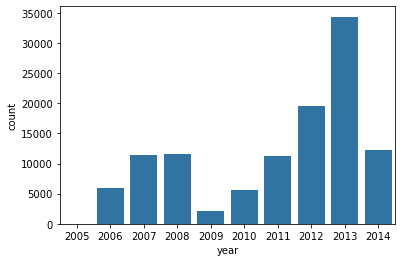

```python
sb.countplot(data=loan_clean,x="year",color=base_color)
```

Most borrowers are from 2007, 2008, 2011 to 2014, especially 2013.

*Discuss the distribution(s) of your variable(s) of interest. Were there any unusual points? Did you need to perform any transformations?*  
The distribution of borrower rate is roughly an unimodal shape, the borrower rate has a high frequency around 0.15. And it is roughly a right skew shape. But, there's a very high frequency around 0.31 and 0.35, making the shape less smooth. I don't think I need to do transformation for this variable.

## Bivariate Exploration

*To start off with, I want to look at the pairwise correlations present between features in the data.*

```python
numeric_vars=["BorrowerRate", "LenderYield", "CreditScoreRangeLower", "CreditScoreRangeUpper", "DebtToIncomeRatio"]
categorical_vars=["CreditGrade", "Term", "ProsperScore", "EmploymentStatus", "IsBorrowerHomeowner","year"]
```

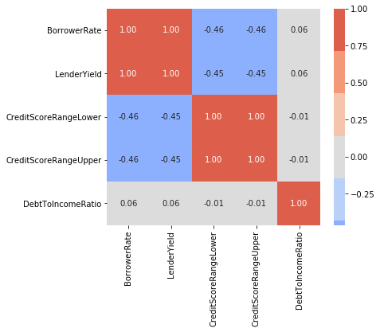

```python
plt.figure(figsize=(6,5));
sb.heatmap(loan_clean[numeric_vars].corr(),annot=True, fmt='0.2f',cmap=sb.color_palette("coolwarm", 7),center=0);
```

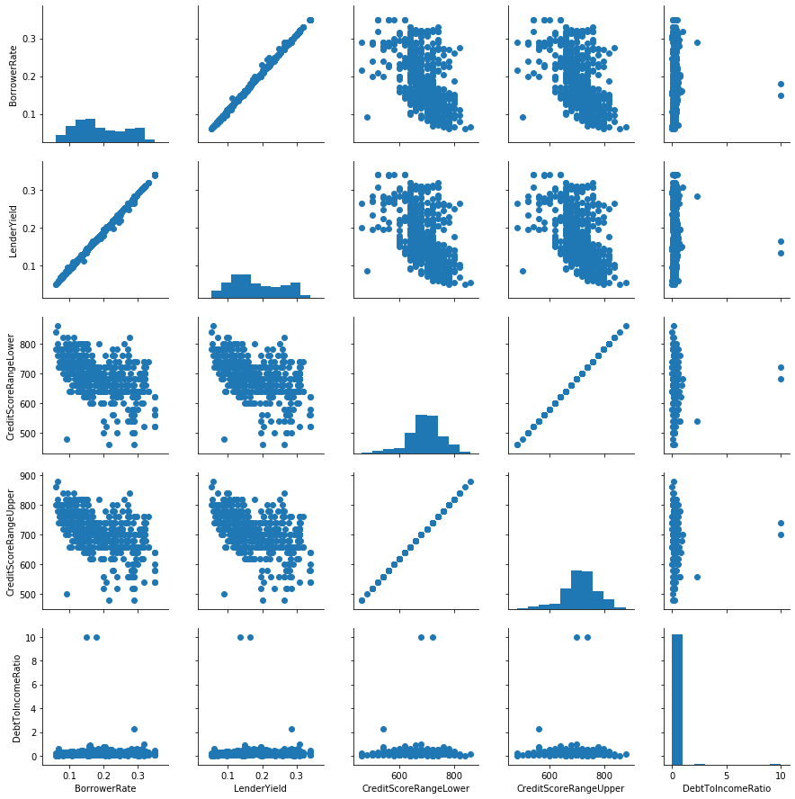

```python
# plot matrix: sample 500 records to make the plots clearer and run faster.
sample=np.random.choice(loan_clean.shape[0],500,replace=False)
loan_sample=loan_clean.loc[sample,:]

g=sb.PairGrid(data=loan_sample,vars=numeric_vars)
g.map_offdiag(plt.scatter);
g.map_diag(plt.hist);
```

```python
loan_clean["creditscore_avg"]=(loan_clean.CreditScoreRangeUpper+loan_clean.CreditScoreRangeUpper)/2
```

It seems there is a negative linear relationship between the borrower rate and CreditScoreRangeUpper and CreditScoreRangeLower (creditscore_avg). I decided to plot a heatmap to check.

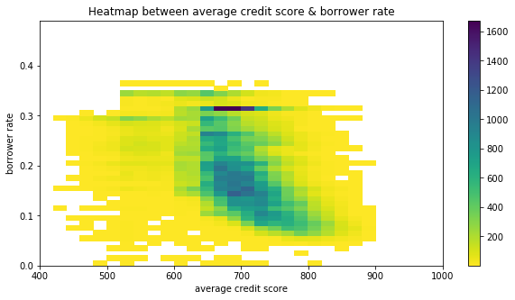

```python
loan_clean_sub1=loan_clean.loc[loan_clean.creditscore_avg.notnull()]
bin_edges10=[np.arange(400,1000,20),np.arange(0,0.5,0.01)]
plt.figure(figsize=(10,5))
plt.hist2d(data=loan_clean_sub1, x="creditscore_avg",y="BorrowerRate",cmap="viridis_r",cmin=0.5,bins=bin_edges10);
plt.xlim((400,1000));
plt.colorbar();
plt.xlabel("average credit score");
plt.ylabel("borrower rate");
plt.title("Heatmap between average credit score & borrower rate")
```

There's indeed a negative linear relationship between average credit score and the borrower rate within the range of 400 to 1000 range of credit score. But the decreasing trend of borrower rate seems getting slower when the average credit score getting higher.

*Let's dig into the relationship between borrower rate and creditscore_avg with other categorical variables.*

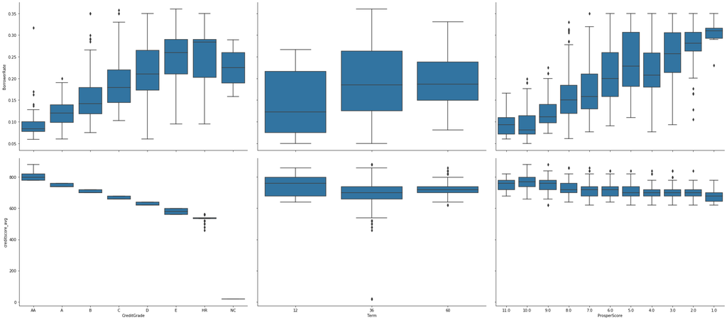

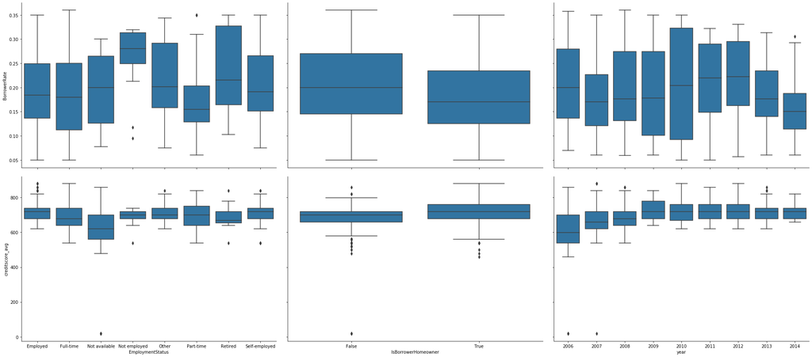

```python
# Plot matrix of numeric features against categorical features.
sample=np.random.choice(loan_clean.shape[0],2000,replace=False)
loan_sample=loan_clean.loc[sample,:]
categorical_vars1=["CreditGrade", "Term", "ProsperScore"]
categorical_vars2=["EmploymentStatus", "IsBorrowerHomeowner","year"]
def box_plot(x,y,**kwargs):
    sb.boxplot(x,y,color=base_color);
g2=sb.PairGrid(data=loan_sample,y_vars=["BorrowerRate","creditscore_avg"],x_vars=categorical_vars1,size=6,aspect=1.5)
g2.map(box_plot)
g3=sb.PairGrid(data=loan_sample,y_vars=["BorrowerRate","creditscore_avg"],x_vars=categorical_vars2,size=6,aspect=1.5)
g3.map(box_plot)
```

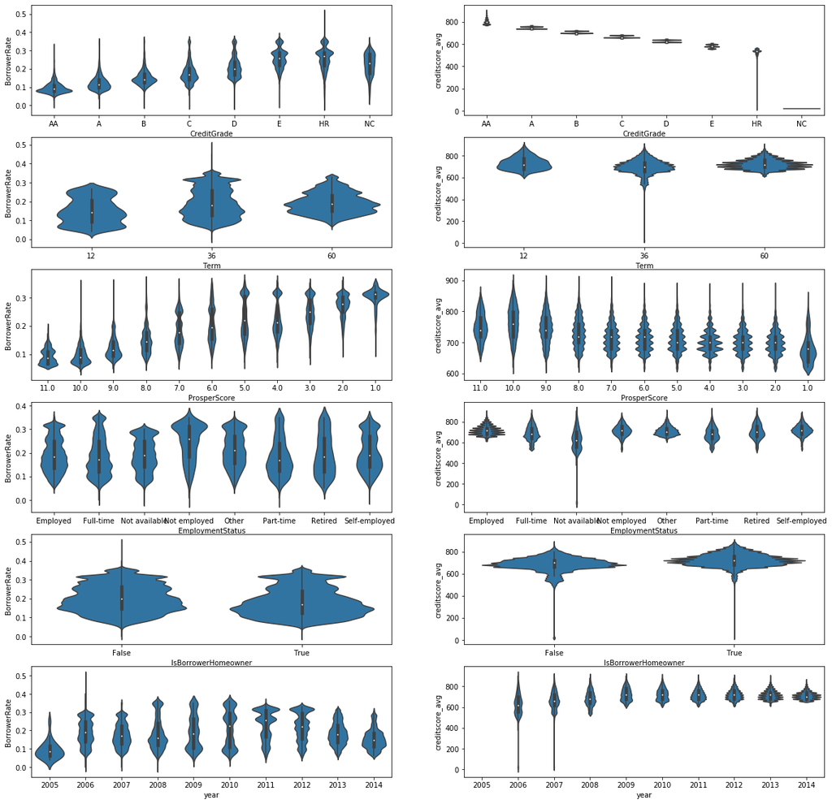

```python
# Plot the categorical variables against the BorrowerRate and creditscore_avg again.
fig,ax=plt.subplots(ncols=2,nrows=6,figsize=[20,20])
for i in range(len(categorical_vars)):
    var=categorical_vars[i]
    sb.violinplot(data=loan_clean, x=var,y="BorrowerRate",ax=ax[i,0],color=base_color)
    sb.violinplot(data=loan_clean, x=var,y="creditscore_avg",ax=ax[i,1],color=base_color)
plt.show()
```

*Finally, let's look at relationships between key categorical features.*

```python
loan_clean.loc[loan_clean.CreditGrade.notnull()].Term.unique()
```

```
[36]
Categories (1, int64): [36]
```

We can see only those loans with 36 months term have info of credit grade.

```python
loan_clean.loc[loan_clean.CreditGrade.notnull()].ProsperScore.unique()
```

```
[NaN]
Categories (0, object): []
```

No record has CreditScore and ProsperScore at the same time.

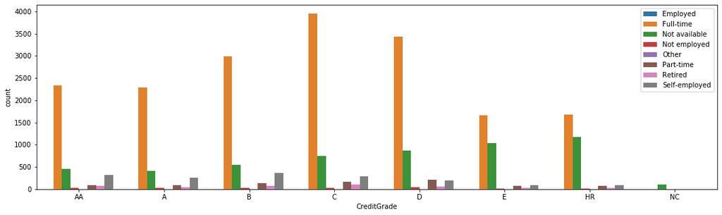

```python
plt.figure(figsize=(18,5));
sb.countplot(data=loan_clean, hue="EmploymentStatus",x="CreditGrade")
plt.legend(loc=1)
```

In each credit grade, large portion of the borrowers are full-time employed. The portion of each employment status category is not the reason that cause the change in credit grade and borrower rate.

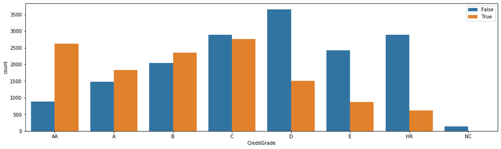

```python
plt.figure(figsize=(18,5));
sb.countplot(data=loan_clean, hue="IsBorrowerHomeowner",x="CreditGrade")
plt.legend(loc=1)
```

There are more homeowners having higher credit grade, while more none-homeowners are having lower credit grade. This can be one of the reason why homeowners havve higher credit grade than non-homeowners in median level and borrower rate is mostly driven by the credit grade.

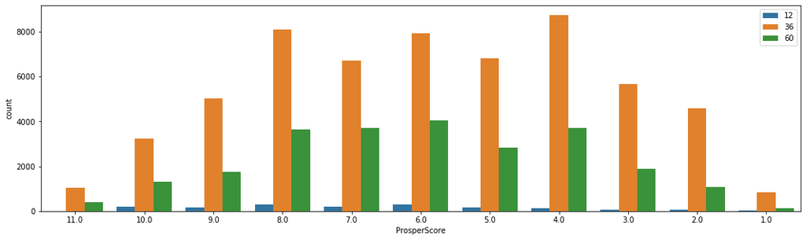

```python
plt.figure(figsize=(18,5));
sb.countplot(data=loan_clean, hue="Term",x="ProsperScore")
plt.legend(loc=1)
```

All terms seem to have similar trend as the prosper score decreases.

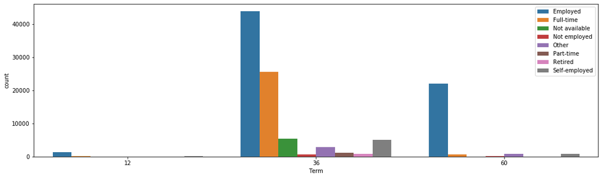

```python
plt.figure(figsize=(18,5));
sb.countplot(data=loan_clean, hue="EmploymentStatus",x="Term")
plt.legend(loc=1)
```

I didn't see any relationship between term and employment status.

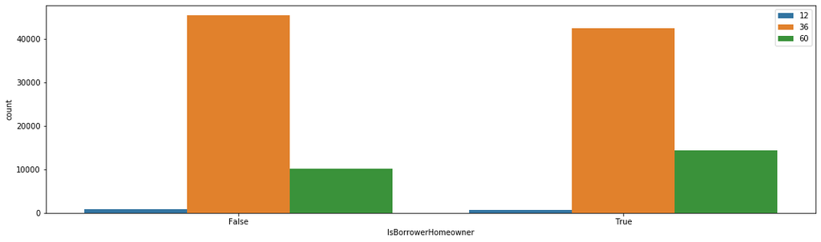

```python
plt.figure(figsize=(18,5));
sb.countplot(data=loan_clean, hue="Term",x="IsBorrowerHomeowner")
plt.legend(loc=1)
```

The portions of each term are similar, I didn't see much relationship between IsBorrowerHomeowner and Term.

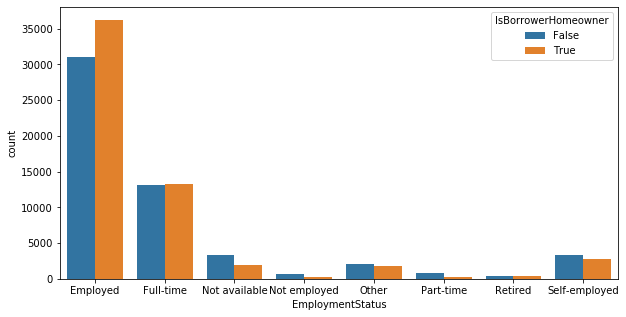

```python
plt.figure(figsize=(10,5))
sb.countplot(data=loan_clean, x="EmploymentStatus",hue="IsBorrowerHomeowner")
```

More homeowners are employed or full-time employed. Less homeowners are short-term employed, retired, self-employed or not employed.

*Talk about some of the relationships you observed in this part of the investigation. How did the feature(s) of interest vary with other features in the dataset?*  
The borrower rate seems to have a high correlation with the credit score. After plotting the heatmap, I noticed there's a negative linear relationship between the average credit score and the borrower rate. There's no obvious relationship between borrower rate and other numeric variables. I was suprised that the DebtToIncomeRatio seemed not related with the borrowerrate,I'll dig it deeper later.  
When I looked at the relationship between borrower rate and categorical variables, I noticed, the longer the term is, the higher the borrower rate will be. And the credit grade looked like a categorical grade based on numeric credit score. Furthermore, prosper score and credit score are kind of similar, the higher the prosper score, the higher the average credit score is. And also, I found that the employed or full-time employed borrowers have lower borrower rate and homeowners have lower borrower rate as well.

*Did you observe any interesting relationships between the other features (not the main feature(s) of interest)?*  
I noticed that borrowers who are employed or full-time employed are often homeowners.

## Multivariate Exploration

In this part, I'm going to explore how the relationship between the borrower rate and the average credit score would be affect by the variables that seem have no effect on borrower rate I analyzed above and some key categorical variables, including: "DebtToIncomeRatio",'EmploymentStatus','IsBorrowerHomeowner','year'.

```python
loan_clean.creditscore_avg.describe()
```

```
count    113346.000000
mean        704.567731
std          66.458275
min          19.000000
25%         679.000000
50%         699.000000
75%         739.000000
max         899.000000
Name: creditscore_avg, dtype: float64
```

```python
def hist2dplot(x, y, **kwargs):
    bins_x = np.arange(15,900,20)
    bins_y = np.arange(0,0.5,0.02)
    plt.hist2d(x, y, bins = [bins_x, bins_y], cmap = "viridis_r", cmin = 0.5)
```

```
(400, 1000)
```

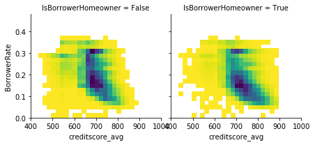

```python
p=sb.FacetGrid(data=loan_clean,col="IsBorrowerHomeowner",col_wrap=3)
p.map(hist2dplot,"creditscore_avg","BorrowerRate")
plt.xlim((400,1000))
```

I noticed when the borrowers are not homeowners, there are more records in upper left (lower credit score and higher borrower rate).

```
(400, 1000)
```

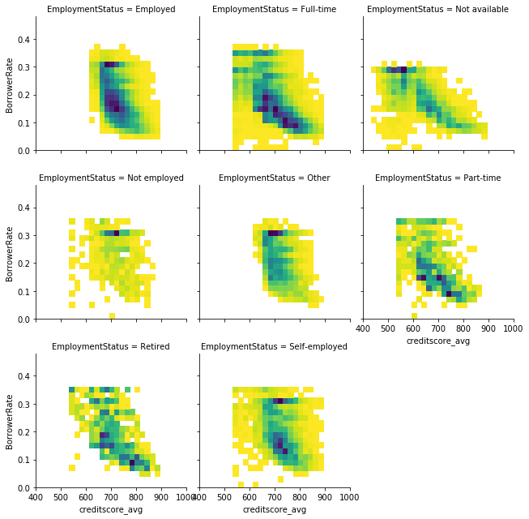

```python
p=sb.FacetGrid(data=loan_clean,col="EmploymentStatus",col_wrap=3)
p.map(hist2dplot,"creditscore_avg","BorrowerRate")
plt.xlim((400,1000))
```

I also notice when borrowers are employed or full-time employed, there are more records on the lower right (high credit score & low borrower rate). It is very obvious in the plot of full-time employed.

```
(400, 1000)
```

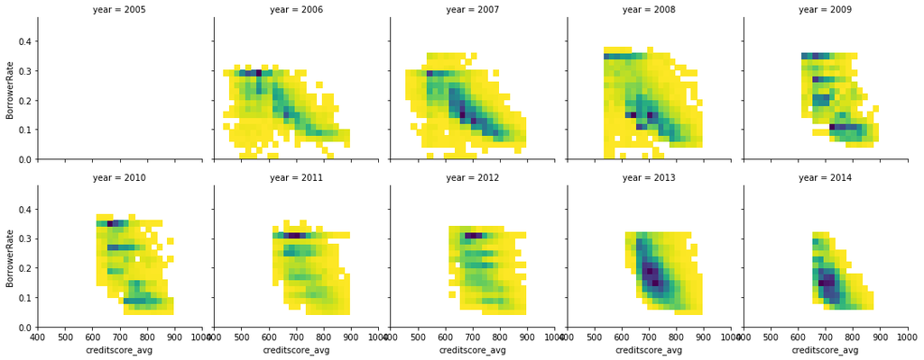

```python
p=sb.FacetGrid(data=loan_clean,col="year",col_wrap=5)
p.map(hist2dplot,"creditscore_avg","BorrowerRate")
plt.xlim((400,1000))
```

In the above plots, as the year went by, I noticed the slope of the average credit score and borrower rate is getting more and more steeper, meaning the borrower rate is getting more and more sensitive to the change of credit score.

```
(400, 1000)
```

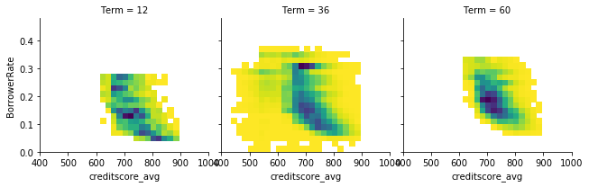

```python
p=sb.FacetGrid(data=loan_clean,col="Term",col_wrap=3)
p.map(hist2dplot,"creditscore_avg","BorrowerRate")
plt.xlim((400,1000))
```

```
(0, 1)
```

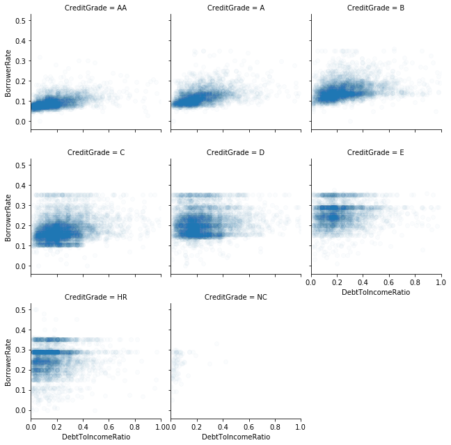

```python
p=sb.FacetGrid(data=loan_clean,col="CreditGrade",col_wrap=3)
p.map(plt.scatter,"DebtToIncomeRatio","BorrowerRate",alpha=0.02)
plt.xlim((0,1))
```

After limiting the range of DebtToIncomeRatio to get rid of the outliers, we can see there's a roughly positive linear relationship between borrower rate and debt to income ratio for each credit grade, especially for grade AA, A, and B.

*Talk about some of the relationships you observed in this part of the investigation. Were there features that strengthened each other in terms of looking at your feature(s) of interest?*

In the bivariate exploration part, I didn't see a clear relationship between the variable DebtToIncomeRatio and BorrowerRate. However, in the multivariate exploration part, I noticed that there's a roughly positive linear relationship between borrower rate and debt to income ratio for each credit grade after limiting the range of DebtToIncomeRatio to get rid of the outliers, this relationship is more obvious for grade AA, A, and B.

*Were there any interesting or surprising interactions between features?¶*